# Particle Filter on R

辻 栄一

2017年12月6日

## はじめに

このサイトを作ろうと思ったきっかけは、会社でやっていた統計関係のテーマを模索していたとき、 時系列データを扱う上で、粒子フィルタに興味をもったからです。 最初のきっかけは[予測に活かす統計モデリングの基本](https://www.amazon.co.jp/dp/B00MOYKGZY/ref=dp-kindle-redirect?_encoding=UTF8&btkr=1) を読んだことでしょう。なにか、会社の収益関連の予測を出来ればいいなぁとか考えながら、統計関係の本を読み漁っていたときに会いました。

本の内容を紹介するとかいうと、やっぱり*ベイズの定理*あたりからやるべきなんでしょうが、 そういうのは、私がやらなくてもいい読み物がいっぱいあるわけです。

というわけで、私としてはこの本に書いてあるコードをRで書いてみたりしたいと考えています。 実は、例題くらいはRでやってもすぐ終わるのですが、多分実務という点では、 遅すぎるということになるのだとは思います。その辺の改良の話はまた別にやることにしましょう。

## 確率分布を粒子で表現する

もちろん、この表現でピンとくる人もいるわけですが、このへんからちょっと考えていけたらと思います。樋口本だと6章あたりまで飛びます。

### 乱数ってなんだろう

乱数について考えてみましょう。たとえば、「0から1の間で**乱数**を発生する」という話はよく聞きます。Excelでやろうと思えば簡単で

```
=RND()
```

とかかけば乱数を獲得できます。本稿ではExcelを使わないので、やりたい人は自分で試してみてください。

課題：0から1の範囲の乱数を10個生成して、その分布を見てみましょう

```r
set.seed(2896)

ens_10 <- runif(10, 0, 1)

show(ens_10)
```

```
##  [1] 0.84647128 0.73266326 0.51273008 0.06287998 0.15256390 0.80261827
##  [7] 0.54228631 0.78833973 0.67694353 0.04236270
```

数字を見ているだけでは、よくわからないので度数分布をみます。

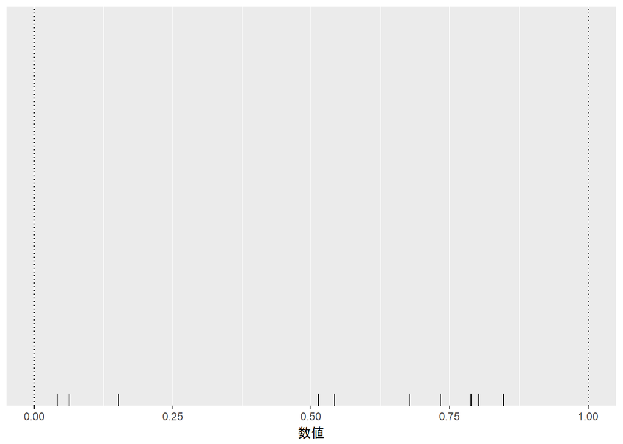